# DSC 423: Data Analysis & Regression

## Assignment 4: Model Building

```
Name: Kushal Navghare
Student ID: 2116916
Honor Statement: I, Kushal Navghare, assure that I have completed this work independently.
The solutions given are entirely my own work.
```

### Question 1

### Find on the D2L a car price dataset. Use R to perform a regression analysis on the dataset. Your submission should take the form of a technical report.

```r
# read csv files
car_df <- read.csv(paste0(dir.path, "data/CARPRICE.csv"))
```

### 1.A] Paste your final model into your submission (just the R output).

```
##
## Call:
## lm(formula = price ~ ., data = df6)
##
## Residuals:
##     Min      1Q  Median      3Q     Max
## -7431.6 -1438.4  -329.2  1163.8 17050.9
##
## Coefficients:
##                          Estimate     Std. Error t value         Pr(>|t|)
## (Intercept)        -14741.1020524   8114.1517284  -1.817          0.07079 .
## wheelbase              90.5269676     92.7841327   0.976          0.33043
## boreratio           -1839.1918748   1135.2051417  -1.620          0.10681
## stroke               -929.9619348    750.4792558  -1.239          0.21677
## carlength             -56.0494318     47.9718991  -1.168          0.24407
## enginelocationrear  16152.0687713   2152.5863748   7.504 0.00000000000212 ***
## sec_ordr_hrspwr         0.1853627      0.0380640   4.870 0.00000229636816 ***
## sec_ordr_crb_wgt        0.0015620      0.0002197   7.108 0.00000000002135 ***
## sec_ordr_carwdth        5.7095207      1.8056333   3.162          0.00182 **
## ---
## Signif. codes:  0 '***' 0.001 '**' 0.01 '*' 0.05 '.' 0.1 ' ' 1
##
## Residual standard error: 3196 on 196 degrees of freedom
## Multiple R-squared:  0.8462, Adjusted R-squared:  0.8399
## F-statistic: 134.8 on 8 and 196 DF,  p-value: < 0.00000000000000022
```

### 1.B] Describe the model building process through which you generated this model.

Let’s look at the data summary.

```r
# summary of cars dataset
str(car_df)
```

```
## 'data.frame':    205 obs. of  23 variables:
##  $ car_ID          : int  1 2 3 4 5 6 7 8 9 10 ...
##  $ CarName         : chr  "alfa-romero giulia" "alfa-romero stelvio" "alfa-romero Quadrifoglio" "audi 100 ls" ...
##  $ fueltype        : chr  "gas" "gas" "gas" "gas" ...
##  $ aspiration      : chr  "std" "std" "std" "std" ...
##  $ doornumber      : chr  "two" "two" "two" "four" ...
##  $ carbody         : chr  "convertible" "convertible" "hatchback" "sedan" ...
##  $ drivewheel      : chr  "rwd" "rwd" "rwd" "fwd" ...
##  $ enginelocation  : chr  "front" "front" "front" "front" ...
##  $ wheelbase       : num  88.6 88.6 94.5 99.8 99.4 ...
##  $ carlength       : num  169 169 171 177 177 ...
##  $ carwidth        : num  64.1 64.1 65.5 66.2 66.4 66.3 71.4 71.4 71.4 67.9 ...
##  $ carheight       : num  48.8 48.8 52.4 54.3 54.3 53.1 55.7 55.7 55.9 52 ...
##  $ curbweight      : int  2548 2548 2823 2337 2824 2507 2844 2954 3086 3053 ...
##  $ enginetype      : chr  "dohc" "dohc" "ohcv" "ohc" ...
##  $ cylindernumber  : chr  "four" "four" "six" "four" ...
##  $ boreratio       : num  3.47 3.47 2.68 3.19 3.19 3.19 3.19 3.19 3.13 3.13 ...
##  $ stroke          : num  2.68 2.68 3.47 3.4 3.4 3.4 3.4 3.4 3.4 3.4 ...
##  $ compressionratio: num  9 9 9 10 8 8.5 8.5 8.5 8.3 7 ...
##  $ horsepower      : int  111 111 154 102 115 110 110 110 140 160 ...
##  $ peakrpm         : int  5000 5000 5000 5500 5500 5500 5500 5500 5500 5500 ...
##  $ citympg         : int  21 21 19 24 18 19 19 19 17 16 ...
##  $ highwaympg      : int  27 27 26 30 22 25 25 25 20 22 ...
##  $ price           : num  13495 16500 16500 13950 17450 ...
```

```r
summary(car_df)
```

```
##      car_ID      CarName            fueltype          aspiration
##  Min.   :  1   Length:205         Length:205         Length:205
##  1st Qu.: 52   Class :character   Class :character   Class :character
##  Median :103   Mode  :character   Mode  :character   Mode  :character
##  Mean   :103
##  3rd Qu.:154
##  Max.   :205
##   doornumber          carbody           drivewheel        enginelocation
##  Length:205         Length:205         Length:205         Length:205
##  Class :character   Class :character   Class :character   Class :character
##  Mode  :character   Mode  :character   Mode  :character   Mode  :character
##
##
##
##    wheelbase        carlength        carwidth       carheight
##  Min.   : 86.60   Min.   :141.1   Min.   :60.30   Min.   :47.80
##  1st Qu.: 94.50   1st Qu.:166.3   1st Qu.:64.10   1st Qu.:52.00
##  Median : 97.00   Median :173.2   Median :65.50   Median :54.10
##  Mean   : 98.76   Mean   :174.0   Mean   :65.91   Mean   :53.72
##  3rd Qu.:102.40   3rd Qu.:183.1   3rd Qu.:66.90   3rd Qu.:55.50
##  Max.   :120.90   Max.   :208.1   Max.   :72.30   Max.   :59.80
##    curbweight    enginetype        cylindernumber       boreratio
##  Min.   :1488   Length:205         Length:205         Min.   :2.54
##  1st Qu.:2145   Class :character   Class :character   1st Qu.:3.15
##  Median :2414   Mode  :character   Mode  :character   Median :3.31
##  Mean   :2556                                         Mean   :3.33
##  3rd Qu.:2935                                         3rd Qu.:3.58
##  Max.   :4066                                         Max.   :3.94
##      stroke      compressionratio   horsepower       peakrpm
##  Min.   :2.070   Min.   : 7.00    Min.   : 48.0   Min.   :4150
##  1st Qu.:3.110   1st Qu.: 8.60    1st Qu.: 70.0   1st Qu.:4800
##  Median :3.290   Median : 9.00    Median : 95.0   Median :5200
##  Mean   :3.255   Mean   :10.14    Mean   :104.1   Mean   :5125
##  3rd Qu.:3.410   3rd Qu.: 9.40    3rd Qu.:116.0   3rd Qu.:5500
##  Max.   :4.170   Max.   :23.00    Max.   :288.0   Max.   :6600
##     citympg        highwaympg        price
##  Min.   :13.00   Min.   :16.00   Min.   : 5118
##  1st Qu.:19.00   1st Qu.:25.00   1st Qu.: 7788
##  Median :24.00   Median :30.00   Median :10295
##  Mean   :25.22   Mean   :30.75   Mean   :13277
##  3rd Qu.:30.00   3rd Qu.:34.00   3rd Qu.:16503
##  Max.   :49.00   Max.   :54.00   Max.   :45400
```

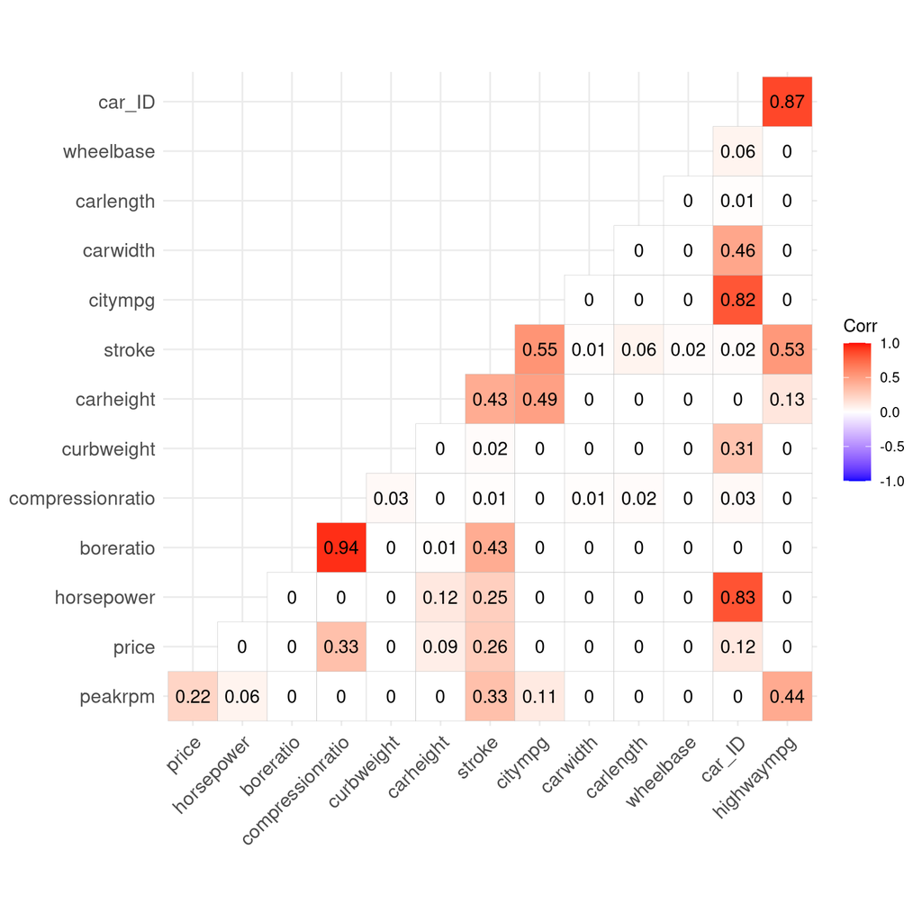

```r
# correlation matrix
corr_df <- cor_pmat(car_df %>%
                      select_if(is.numeric))

ggcorrplot(corr_df, lab = TRUE, hc.order = TRUE, type = "lower")
```

Let’s look at the distribution plot of the target variable that is carprice.

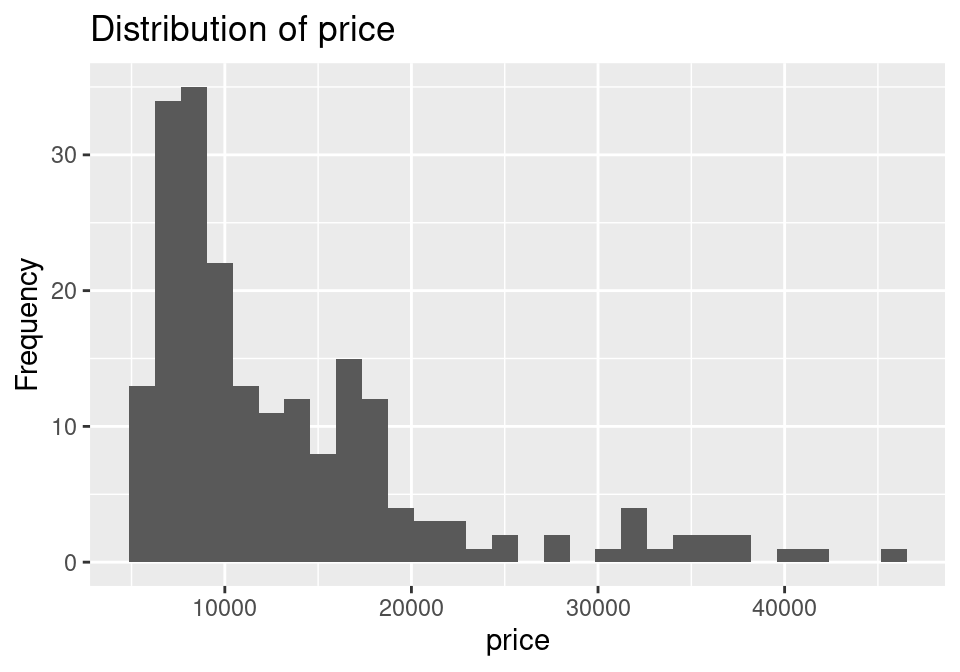

```r
# histogram
plt_1 <- ggplot(data = car_df, aes(price))
plt_1 + geom_histogram() +
  ggtitle("Distribution of price") +
  xlab("price") +
  ylab("Frequency")
```

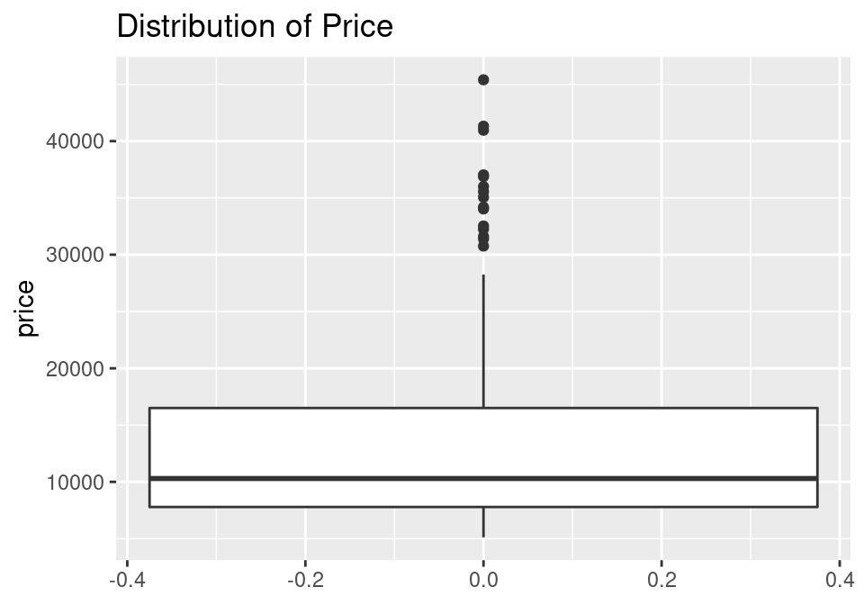

```r
# boxplot
plt_2 <- ggplot(data = car_df, aes(y = price))
plt_2 + geom_boxplot() +
  ggtitle("Distribution of Price")
```

From looking at the distribution of target variable, it looks like there are a lot of outliers in the data. However, we’re unable to decide the treatment of these outliers as we don’t know the process behind how the data was collected. Hence, it is unable to justify whether they are the actual outliers or real values within the data. Let’s see if the price of car varies for certain categories and that can give us more information.

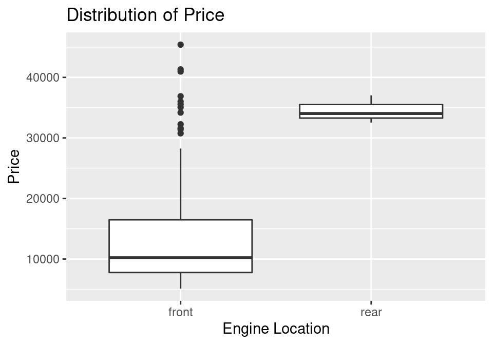

```r
# boxplot of price with other categories
plt_3 <- ggplot(data = car_df, aes(x = enginelocation, y = price))
plt_3 + geom_boxplot() +
  ggtitle("Distribution of Price") +
  xlab("Engine Location") +
  ylab("Price")
```

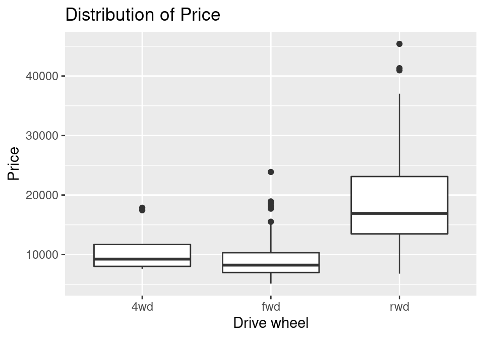

```r
plt_3 <- ggplot(data = car_df, aes(x = drivewheel, y = price))
plt_3 + geom_boxplot() +
  ggtitle("Distribution of Price") +
  xlab("Drive wheel") +
  ylab("Price")
```

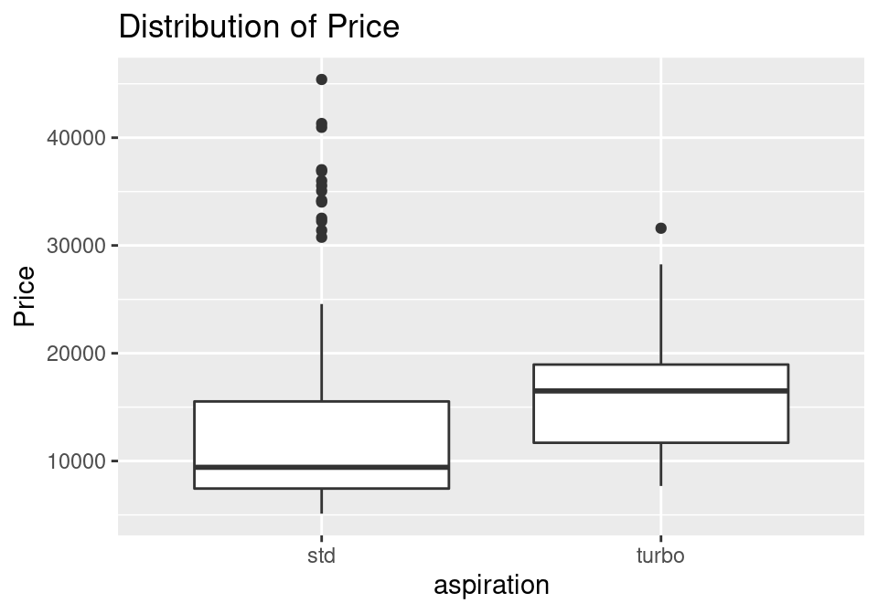

```r
plt_3 <- ggplot(data = car_df, aes(x = aspiration, y = price))
plt_3 + geom_boxplot() +
  ggtitle("Distribution of Price") +
  xlab("aspiration") +
  ylab("Price")
```

Looks like the car price ranges a lot based on engine location. Also, it changes with aspiration, wheeldrive, etc.

Let’s see if we can model the car price using all features as a baseline model.

```r
# building a model (baseline)
# lets try building a model using all the available features
car_model_1 <- lm(price~., data=car_df %>% select(-c(car_ID, CarName)))

summary(car_model_1)
```

```
##
## Call:
## lm(formula = price ~ ., data = car_df %>% select(-c(car_ID, CarName)))
##
## Residuals:
##     Min      1Q  Median      3Q     Max
## -6707.4 -1162.4     0.0   964.8 10734.1
##
## Coefficients: (1 not defined because of singularities)
##                         Estimate  Std. Error t value           Pr(>|t|)
## (Intercept)          -23181.5513  15785.4947  -1.469           0.143796
## fueltypegas          -12248.4571   6608.6888  -1.853           0.065550 .
## aspirationturbo        -541.4416    808.4917  -0.670           0.503956
## doornumbertwo           532.7551    564.7942   0.943           0.346872
## carbodyhardtop        -2526.0026   1436.2808  -1.759           0.080415 .
## carbodyhatchback      -3613.6703   1260.2096  -2.868           0.004658 **
## carbodysedan          -2430.3999   1389.7789  -1.749           0.082126 .
## carbodywagon          -4007.7189   1518.0923  -2.640           0.009058 **
## drivewheelfwd           566.7528   1073.6663   0.528           0.598276
## drivewheelrwd          1117.2436   1252.5640   0.892           0.373665
## enginelocationrear     8641.7547   2571.2983   3.361           0.000958 ***
## wheelbase               129.8973     91.6325   1.418           0.158130
## carlength               -89.2307     50.9774  -1.750           0.081843 .
## carwidth                646.1281    252.0998   2.563           0.011239 *
## carheight                76.3184    126.7823   0.602           0.547995
## curbweight                7.2443      1.5708   4.612 0.0000077897278735 ***
## enginetypedohcv      -17199.7248   4296.4183  -4.003 0.0000929558227460 ***
## enginetypel           -1656.1236   1611.3385  -1.028           0.305498
## enginetypeohc          2882.5025    955.6964   3.016           0.002951 **
## enginetypeohcf          832.0218   1627.1104   0.511           0.609766
## enginetypeohcv        -5731.4457   1300.2016  -4.408 0.0000183690636165 ***
## enginetyperotor      -15542.0884   2953.3374  -5.263 0.0000004213723491 ***
## cylindernumberfive   -17327.0663   2195.6102  -7.892 0.0000000000003410 ***
## cylindernumberfour   -19924.9575   2423.3025  -8.222 0.0000000000000481 ***
## cylindernumbersix    -12900.0597   1882.5061  -6.853 0.0000000001258059 ***
## cylindernumberthree  -11988.9198   4206.9737  -2.850           0.004913 **
## cylindernumbertwelve  -5268.2877   4059.0448  -1.298           0.196065
## cylindernumbertwo             NA          NA      NA                 NA
## boreratio              1705.0707   1469.9216   1.160           0.247676
## stroke                -2848.8630    858.9764  -3.317           0.001113 **
## compressionratio       -783.0229    489.9616  -1.598           0.111860
## horsepower               41.5345     20.2302   2.053           0.041587 *
## peakrpm                   1.4059      0.5918   2.376           0.018619 *
## citympg                 -89.0581    150.0583  -0.593           0.553637
## highwaympg              192.0314    140.8974   1.363           0.174701
## ---
## Signif. codes:  0 '***' 0.001 '**' 0.01 '*' 0.05 '.' 0.1 ' ' 1
##
## Residual standard error: 2347 on 171 degrees of freedom
## Multiple R-squared:  0.9276, Adjusted R-squared:  0.9137
## F-statistic: 66.44 on 33 and 171 DF,  p-value: < 0.00000000000000022
```

From the results, it looks like the model is working very well, with adjusted R-squared value of 0.91. However, by using all the features available, we’re building a very complex model, which is difficult to interpret.

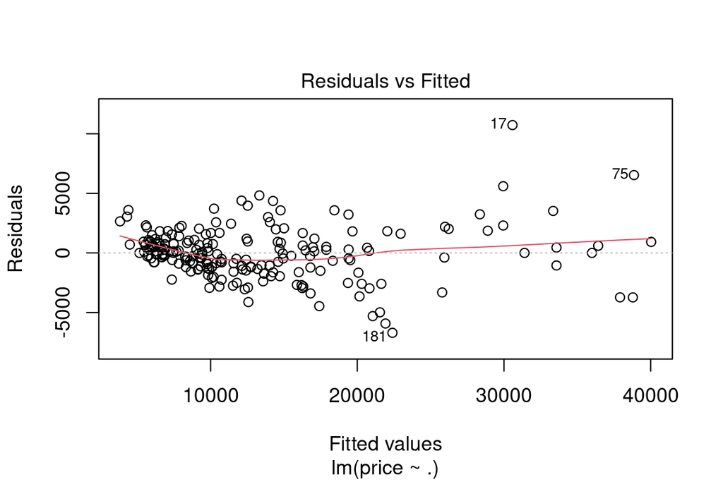

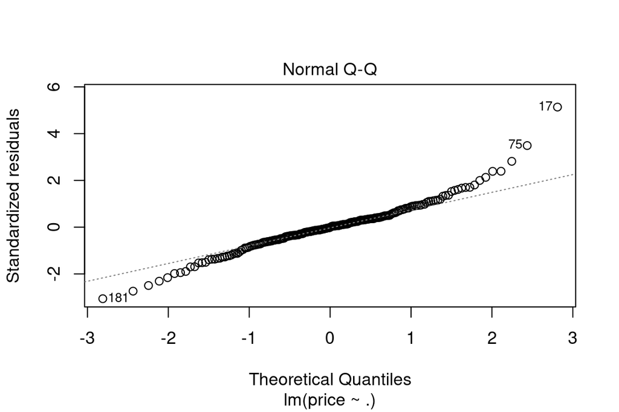

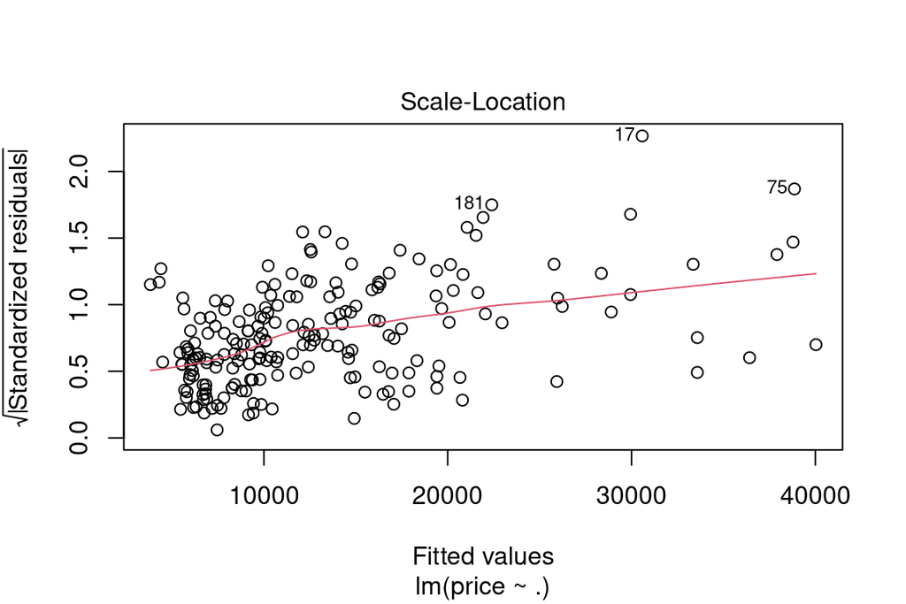

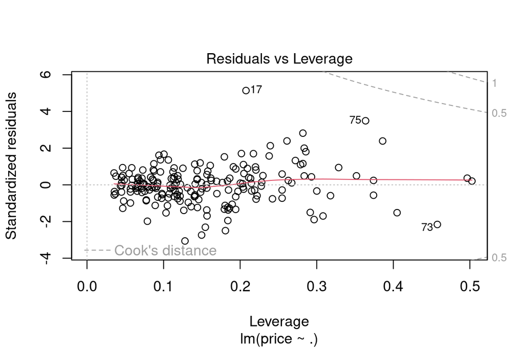

```r
# model residual plots
plot(car_model_1)
```

Let’s try a model considering only few features that affect price

```r
# considering only few features that affect price
car_model_2 <- lm(price~compressionratio+boreratio+enginelocation+aspiration+drivewheel,
                  data = car_df)

summary(car_model_2)
```

```
##
## Call:
## lm(formula = price ~ compressionratio + boreratio + enginelocation +
##     aspiration + drivewheel, data = car_df)
##
## Residuals:
##      Min       1Q   Median       3Q      Max
## -11057.8  -2078.0   -974.4    954.7  24678.3
##
## Coefficients:
##                      Estimate Std. Error t value  Pr(>|t|)
## (Intercept)        -12143.192   6720.250  -1.807  0.072287 .
## compressionratio       -8.631    106.616  -0.081  0.935558
## boreratio            6687.341   1878.102   3.561  0.000463 ***
## enginelocationrear  14220.462   3390.131   4.195 0.0000412 ***
## aspirationturbo      1875.481   1120.763   1.673  0.095828 .
## drivewheelfwd        -162.370   2012.814  -0.081  0.935787
## drivewheelrwd        7522.070   2052.124   3.666  0.000317 ***
## ---
## Signif. codes:  0 '***' 0.001 '**' 0.01 '*' 0.05 '.' 0.1 ' ' 1
##
## Residual standard error: 5687 on 198 degrees of freedom
## Multiple R-squared:  0.5082, Adjusted R-squared:  0.4933
## F-statistic:  34.1 on 6 and 198 DF,  p-value: < 0.00000000000000022
```

Let’s look at the model plots now.

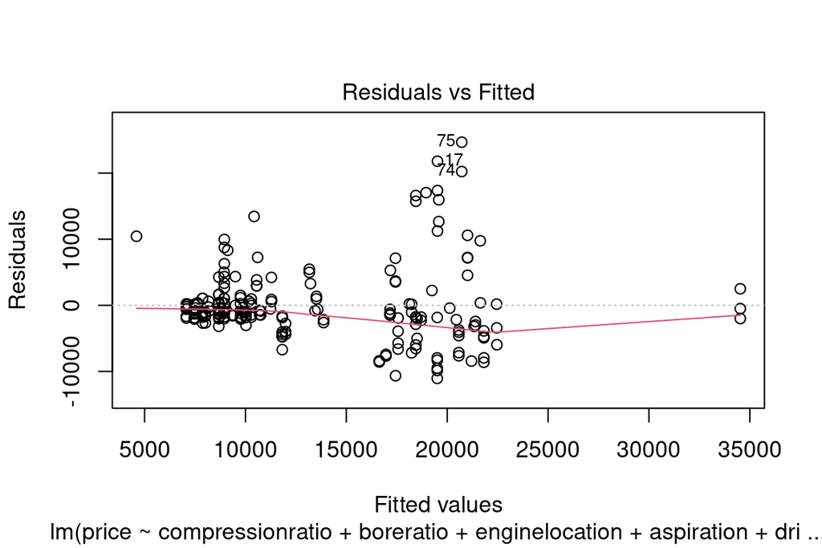

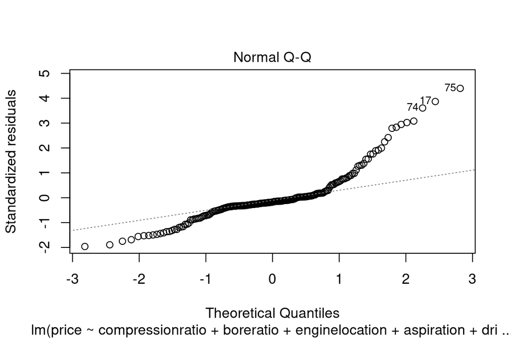

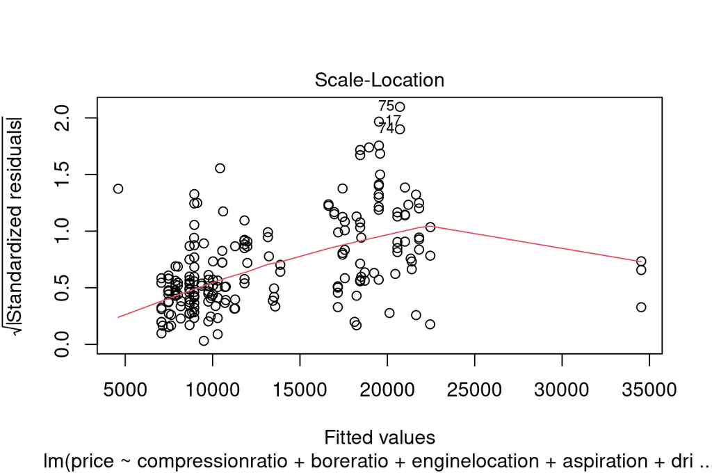

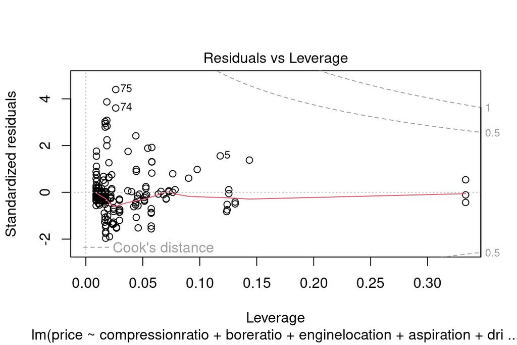

```r
# model residual plots
plot(car_model_2)
```

From the plots above, we can see that the residuals are not normal. Meaning, it violates the assumption of residuals for linear regression.

Let’s try building a different model with only selected features.

```r
# selected features
df1 <- car_df %>%
  select(price, wheelbase, peakrpm, citympg, highwaympg, curbweight, boreratio, stroke,
         carlength, carwidth, carheight, compressionratio, horsepower)

car_model_3 <- lm(price ~., data = df1)

summary(car_model_3)
```

```
##
## Call:
## lm(formula = price ~ ., data = df1)
##
## Residuals:
##     Min      1Q  Median      3Q     Max
## -9053.7 -1891.3  -122.9  1533.2 15769.3
##
## Coefficients:
##                     Estimate  Std. Error t value       Pr(>|t|)
## (Intercept)      -44316.0084  17862.9561  -2.481       0.013965 *
## wheelbase           147.1771    117.5166   1.252       0.211950
## peakrpm               0.3596      0.7341   0.490       0.624779
## citympg               6.9710    203.0663   0.034       0.972651
## highwaympg           76.4433    186.1389   0.411       0.681766
## curbweight            6.7739      1.9179   3.532       0.000517 ***
## boreratio         -1288.9250   1398.7822  -0.921       0.357966
## stroke            -1955.3318    898.8813  -2.175       0.030830 *
## carlength           -77.4845     64.9701  -1.193       0.234491
## carwidth            509.6832    287.8880   1.770       0.078244 .
## carheight            -9.4669    157.0258  -0.060       0.951989
## compressionratio    157.3291     95.0624   1.655       0.099556 .
## horsepower          104.1269     16.0550   6.486 0.000000000731 ***
## ---
## Signif. codes:  0 '***' 0.001 '**' 0.01 '*' 0.05 '.' 0.1 ' ' 1
##
## Residual standard error: 3732 on 192 degrees of freedom
## Multiple R-squared:  0.7946, Adjusted R-squared:  0.7818
## F-statistic:  61.9 on 12 and 192 DF,  p-value: < 0.00000000000000022
```

From the results, the adjusted R-squared value improved from 0.49 to 0.78. Yet, by looking at p-values, only a few set of variables are significant in this case.

Let’s build a model by eliminating features with highest p-value.

```r
df3 <- car_df %>%
  select(price, wheelbase, peakrpm, curbweight, boreratio, stroke,
         carlength, carwidth, compressionratio, horsepower)

car_model_4 <- lm(price ~., data = df3)

summary(car_model_4)
```

```
##
## Call:
## lm(formula = price ~ ., data = df3)
##
## Residuals:
##     Min      1Q  Median      3Q     Max
## -8358.9 -1939.4  -222.1  1444.1 16048.8
##
## Coefficients:
##                     Estimate  Std. Error t value       Pr(>|t|)
## (Intercept)      -38908.7502  15112.6797  -2.575       0.010778 *
## wheelbase           153.2918    106.4498   1.440       0.151460
## peakrpm               0.1892      0.7049   0.268       0.788693
## curbweight            5.9880      1.7005   3.521       0.000534 ***
## boreratio         -1428.2025   1376.5963  -1.037       0.300793
## stroke            -1912.0709    874.2868  -2.187       0.029932 *
## carlength           -86.7251     59.0849  -1.468       0.143768
## carwidth            516.3950    278.6021   1.854       0.065318 .
## compressionratio    201.0552     80.2389   2.506       0.013039 *
## horsepower          103.4936     15.3117   6.759 0.000000000157 ***
## ---
## Signif. codes:  0 '***' 0.001 '**' 0.01 '*' 0.05 '.' 0.1 ' ' 1
##
## Residual standard error: 3712 on 195 degrees of freedom
## Multiple R-squared:  0.7937, Adjusted R-squared:  0.7842
## F-statistic: 83.35 on 9 and 195 DF,  p-value: < 0.00000000000000022
```

We are able to achieve the similar adj R-squared value with limited set of features. Our this version of model is less complex, making it more interpretable.

Let’s see if we can build even less complex version of model with limited set of features which are significant to reject the null hypothesis and accept the alternate one.

```r
df4 <- car_df %>%
  select(price, carwidth, curbweight, stroke, compressionratio, horsepower)
```

```r
car_model_5 <- lm(price ~., data = df4)

summary(car_model_5)
```

```
##
## Call:
## lm(formula = price ~ ., data = df4)
##
## Residuals:
##     Min      1Q  Median      3Q     Max
## -7859.8 -2228.2  -112.9  1444.1 15687.1
##
## Coefficients:
##                    Estimate Std. Error t value            Pr(>|t|)
## (Intercept)      -43836.031  14025.751  -3.125             0.00204 **
## carwidth            559.579    245.219   2.282             0.02355 *
## curbweight            5.158      1.209   4.265 0.00003081657081795 ***
## stroke            -1599.712    855.158  -1.871             0.06286 .
## compressionratio    202.541     77.061   2.628             0.00925 **
## horsepower           98.013     11.409   8.591 0.00000000000000251 ***
## ---
## Signif. codes:  0 '***' 0.001 '**' 0.01 '*' 0.05 '.' 0.1 ' ' 1
##
## Residual standard error: 3717 on 199 degrees of freedom
## Multiple R-squared:  0.7888, Adjusted R-squared:  0.7835
## F-statistic: 148.7 on 5 and 199 DF,  p-value: < 0.00000000000000022
```

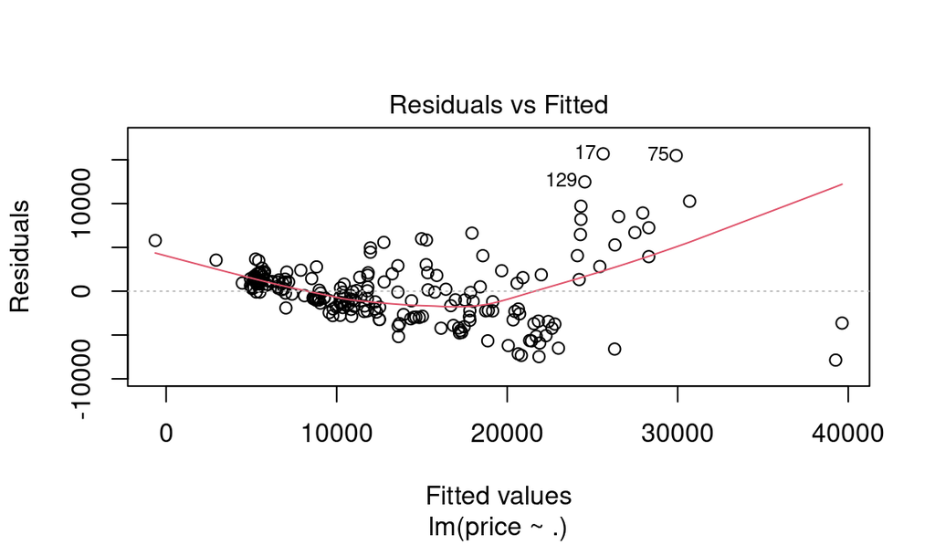

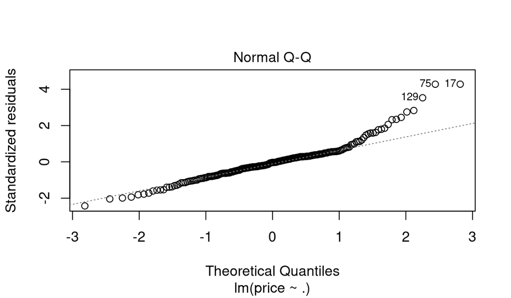

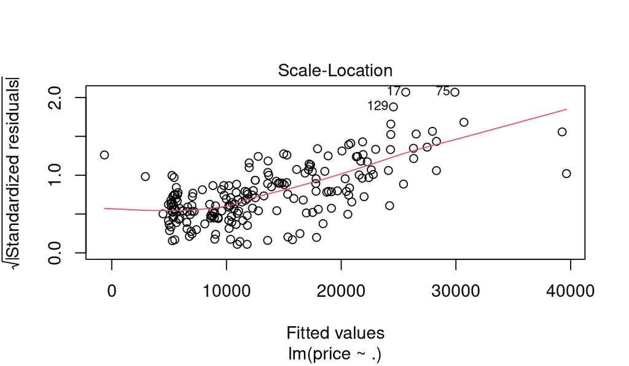

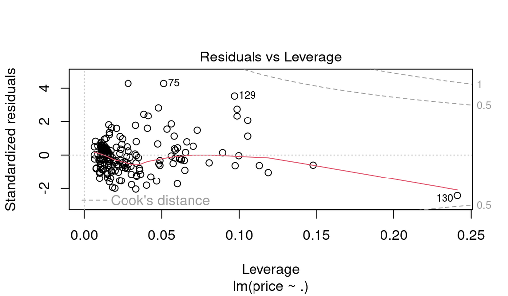

```r
plot(car_model_5)
```

To summarise the model building process:

### 1.C]

### What significant second-order terms did you find, if any? Did you try all second-order terms? Did you look at scatter plots to determine which second-ordert erms to evaluate? Discuss the benefits and drawbacks of these two strategies.

Now, we will see if there are any second order terms that we can create which might improve the current performance of the model.

In order to do that, let’s look at the data again and see if there any second order transformation possible.

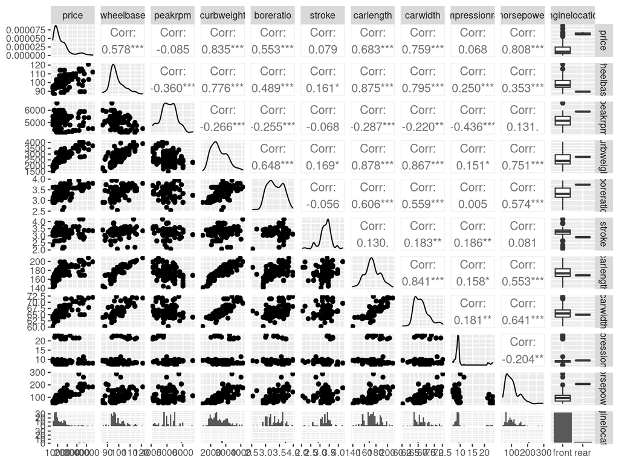

```r
# selecting few features
df5 <- car_df %>%
  select(price, wheelbase, peakrpm, curbweight, boreratio, stroke,
         carlength, carwidth, compressionratio, horsepower, enginelocation)

ggpairs(df5)
```

From the distribution of above features, the second order terms can be created to utilize the bi-modal distribution of these features.

```r
df6 <- df5 %>%
  mutate(sec_ordr_hrspwr = horsepower^2,
         sec_ordr_crb_wgt = curbweight^2,
         sec_ordr_carwdth = carwidth^2) %>%
  select(-c(horsepower, curbweight, carwidth, compressionratio, peakrpm))

car_model_6 <- lm(price~., data = df6)
summary(car_model_6)
```

```
##
## Call:
## lm(formula = price ~ ., data = df6)
##
## Residuals:
##     Min      1Q  Median      3Q     Max
## -7431.6 -1438.4  -329.2  1163.8 17050.9
##
## Coefficients:
##                          Estimate     Std. Error t value         Pr(>|t|)
## (Intercept)        -14741.1020524   8114.1517284  -1.817          0.07079 .
## wheelbase              90.5269676     92.7841327   0.976          0.33043
## boreratio           -1839.1918748   1135.2051417  -1.620          0.10681
## stroke               -929.9619348    750.4792558  -1.239          0.21677
## carlength             -56.0494318     47.9718991  -1.168          0.24407
## enginelocationrear  16152.0687713   2152.5863748   7.504 0.00000000000212 ***
## sec_ordr_hrspwr         0.1853627      0.0380640   4.870 0.00000229636816 ***
## sec_ordr_crb_wgt        0.0015620      0.0002197   7.108 0.00000000002135 ***
## sec_ordr_carwdth        5.7095207      1.8056333   3.162          0.00182 **
## ---
## Signif. codes:  0 '***' 0.001 '**' 0.01 '*' 0.05 '.' 0.1 ' ' 1
##
## Residual standard error: 3196 on 196 degrees of freedom
## Multiple R-squared:  0.8462, Adjusted R-squared:  0.8399
## F-statistic: 134.8 on 8 and 196 DF,  p-value: < 0.00000000000000022
```

### 1.D]

### What significant interaction terms did you find, if any? Did you try all combinations of interaction terms? Do you think that is an appropriate strategy? What happens to the number of interaction terms as the number of independent terms increases?

Now let’s see if we can produce some interaction terms to improve the performance of the model further.

In order to understand what possible interaction are possible, lets look at pair plot of all features with different groups (categorical features).

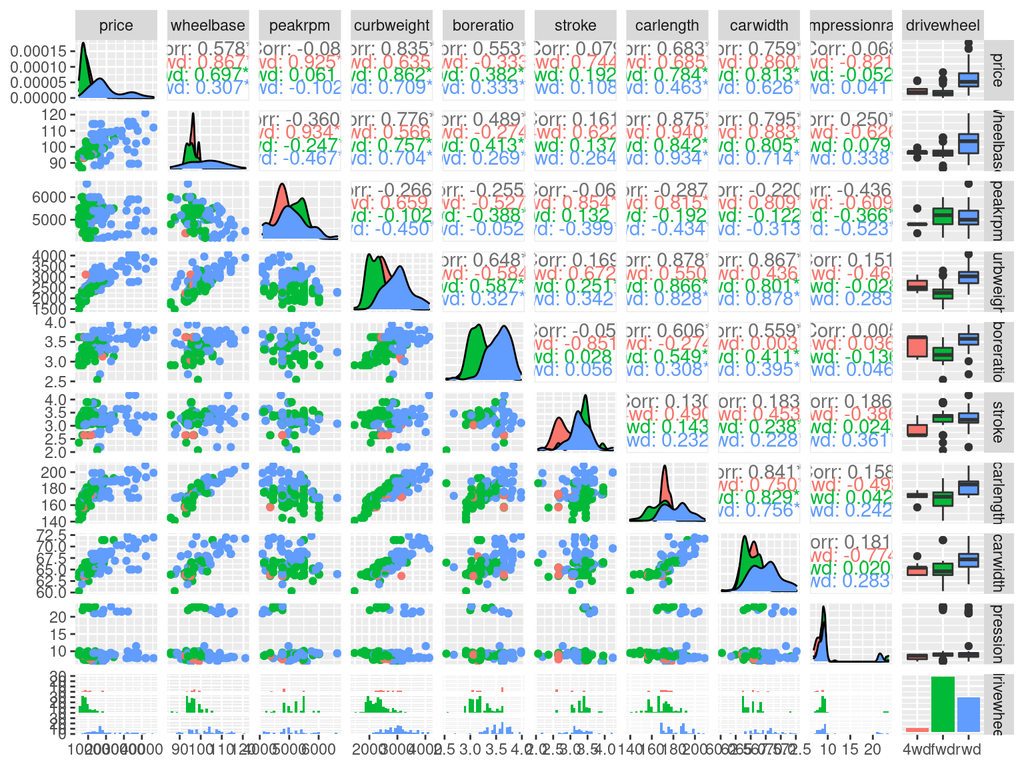

```r
df7 <- car_df %>%
  select(c(price, wheelbase, peakrpm, curbweight, boreratio, stroke, carlength,
           carwidth, compressionratio, drivewheel))

ggpairs(df7, aes(color = drivewheel), size = 1)
```

Looks like drivewheel might have interaction with a couple of features like carlength, carwidth, boreratio, etc. Let’s try few of the interactions below.

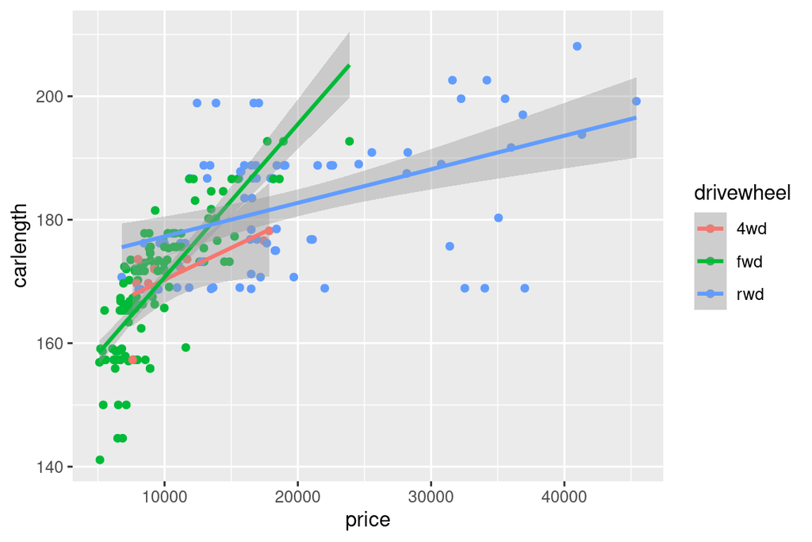

```r
plt_4 <- ggplot(df7, aes(x = price, y = carlength, color = drivewheel))
plt_4 + geom_point() +
  geom_smooth(method = "lm")
```

Interaction can be seen in 2 of the 3 categories of drivewheel. This will clearly show that such interaction can be modeled into linear regression.

```r
car_model_7 <- lm(price~ peakrpm + curbweight +
                    stroke + factor(drivewheel):carlength, data = df7)

summary(car_model_7)
```

```
##
## Call:
## lm(formula = price ~ peakrpm + curbweight + stroke + factor(drivewheel):carlength,
##     data = df7)
##
## Residuals:
##     Min      1Q  Median      3Q     Max
## -9973.5 -2053.4   -83.5  1730.8 17897.5
##
## Coefficients:
##                                   Estimate Std. Error t value
## (Intercept)                     -7106.9675  8413.2012  -0.845
## peakrpm                             2.0114     0.6383   3.151
## curbweight                         15.7103     1.4379  10.926
## stroke                          -2002.0112  1009.3572  -1.983
## factor(drivewheel)4wd:carlength  -156.6849    53.3143  -2.939
## factor(drivewheel)fwd:carlength  -136.6830    50.6571  -2.698
## factor(drivewheel)rwd:carlength  -131.0193    51.7529  -2.532
##                                             Pr(>|t|)
## (Intercept)                                  0.39928
## peakrpm                                      0.00188 **
## curbweight                      < 0.0000000000000002 ***
## stroke                                       0.04870 *
## factor(drivewheel)4wd:carlength              0.00369 **
## factor(drivewheel)fwd:carlength              0.00757 **
## factor(drivewheel)rwd:carlength              0.01213 *
## ---
## Signif. codes:  0 '***' 0.001 '**' 0.01 '*' 0.05 '.' 0.1 ' ' 1
##
## Residual standard error: 4125 on 198 degrees of freedom
## Multiple R-squared:  0.7412, Adjusted R-squared:  0.7333
## F-statistic: 94.51 on 6 and 198 DF,  p-value: < 0.00000000000000022
```

Here, we’ve considered interaction between drivewheel and carlength. As we can see from p-values, the interaction between these variables is very significant. Although, this model only achieved adjusted R-squared of 0.73, all the features used in this model are very significant.

Let’s see if adding more independent terms have any effect on model performance.

```r
car_model_8 <- lm(price ~ wheelbase + peakrpm + curbweight + boreratio + stroke +
                    carwidth + compressionratio + factor(drivewheel):carlength,
                  data = df7)

summary(car_model_8)
```

```
##
## Call:
## lm(formula = price ~ wheelbase + peakrpm + curbweight + boreratio +
##     stroke + carwidth + compressionratio + factor(drivewheel):carlength,
##     data = df7)
##
## Residuals:
##     Min      1Q  Median      3Q     Max
## -7907.7 -1924.7  -354.9  1411.4 17128.7
##
## Coefficients:
##                                    Estimate  Std. Error t value
## (Intercept)                     -51295.8373  16706.7365  -3.070
## wheelbase                         -212.1620    107.9281  -1.966
## peakrpm                              1.4249      0.7309   1.949
## curbweight                          12.4463      1.6724   7.442
## boreratio                         -150.5998   1514.5443  -0.099
## stroke                           -1783.0795   1007.1378  -1.770
## carwidth                          1079.0448    304.1903   3.547
## compressionratio                   -22.7183     83.0550  -0.274
## factor(drivewheel)4wd:carlength   -122.7353     67.8124  -1.810
## factor(drivewheel)fwd:carlength   -107.9639     65.8603  -1.639
## factor(drivewheel)rwd:carlength    -97.0998     67.3418  -1.442
##                                         Pr(>|t|)
## (Intercept)                             0.002445 **
## wheelbase                               0.050752 .
## peakrpm                                 0.052679 .
## curbweight                      0.00000000000314 ***
## boreratio                               0.920895
## stroke                                  0.078224 .
## carwidth                                0.000488 ***
## compressionratio                        0.784735
## factor(drivewheel)4wd:carlength         0.071855 .
## factor(drivewheel)fwd:carlength         0.102774
## factor(drivewheel)rwd:carlength         0.150944
## ---
## Signif. codes:  0 '***' 0.001 '**' 0.01 '*' 0.05 '.' 0.1 ' ' 1
##
## Residual standard error: 4027 on 194 degrees of freedom
## Multiple R-squared:  0.7583, Adjusted R-squared:  0.7459
## F-statistic: 60.87 on 10 and 194 DF,  p-value: < 0.00000000000000022
```

As the number of independent terms increases, the significance of interaction terms and its factors decreased. We can no longer accept the alternate hypothesis of thes interaction terms as p-value is not significant.

The adj R-squared improved from 0.73 to 0.74. This is very little improvement to the performance.

### 1.E] iscuss your final model. Evaluate the t-tests, F-Test and adj-R2 accordingly. Do you think this is a “good” model? Explain.

```r
# selecting few features
df5 <- car_df %>%
  select(price, wheelbase, peakrpm, curbweight, boreratio, stroke,
         carlength, carwidth, compressionratio, horsepower, enginelocation)

# second order transformation
df5 <- df5 %>%
  mutate(sec_ordr_hrspwr = horsepower^2,
         sec_ordr_crb_wgt = curbweight^2,
         sec_ordr_carwdth = carwidth^2) %>%
  select(-c(horsepower, curbweight, carwidth, compressionratio, peakrpm))

# build model
car_model_6 <- lm(price~., data = df6)

# model output
summary(car_model_6)
```

```
##
## Call:
## lm(formula = price ~ ., data = df6)
##
## Residuals:
##     Min      1Q  Median      3Q     Max
## -7431.6 -1438.4  -329.2  1163.8 17050.9
##
## Coefficients:
##                          Estimate     Std. Error t value         Pr(>|t|)
## (Intercept)        -14741.1020524   8114.1517284  -1.817          0.07079 .
## wheelbase              90.5269676     92.7841327   0.976          0.33043
## boreratio           -1839.1918748   1135.2051417  -1.620          0.10681
## stroke               -929.9619348    750.4792558  -1.239          0.21677
## carlength             -56.0494318     47.9718991  -1.168          0.24407
## enginelocationrear  16152.0687713   2152.5863748   7.504 0.00000000000212 ***
## sec_ordr_hrspwr         0.1853627      0.0380640   4.870 0.00000229636816 ***
## sec_ordr_crb_wgt        0.0015620      0.0002197   7.108 0.00000000002135 ***
## sec_ordr_carwdth        5.7095207      1.8056333   3.162          0.00182 **
## ---
## Signif. codes:  0 '***' 0.001 '**' 0.01 '*' 0.05 '.' 0.1 ' ' 1
##
## Residual standard error: 3196 on 196 degrees of freedom
## Multiple R-squared:  0.8462, Adjusted R-squared:  0.8399
## F-statistic: 134.8 on 8 and 196 DF,  p-value: < 0.00000000000000022
```

1. The null hypothesis: There is no relationship between ANY of the independent variables and dependent variable (i.e. B1=B2=B3…=Bn = 0)
2. Alternate hypothesis: At least one independent variable is related to dependent variable. (B1 != 0)

In our model, the p-value of F-test is < 0.00000000000000022, meaning that we can reject the null hypothesis and assume that at least one independent variable is present which is able to explain the variance in dependent variable.

This concludes that we can ignore the intercept only model (B1,B2, B3, …Bn = 0) and use the complex version of model to predict the dependent variable using significant features.

### 1.F] Include your code an appendix.

### Appendix:

```r
library(dplyr)
library(ggplot2)
library(GGally)
library(ggcorrplot)

# read csv files
car_df <- read.csv("../Downloads/CARPRICE.csv")

# summary of cars dataset
str(car_df)

summary(car_df)

# correlation matrix
corr_df <- cor_pmat(car_df %>%
                      select_if(is.numeric))

# correlation plot
ggcorrplot(corr_df, lab = TRUE, hc.order = TRUE, type = "lower")

# histogram
plt_1 <- ggplot(data = car_df, aes(price))
plt_1 + geom_histogram() +
  ggtitle("Distribution of price") +
  xlab("price") +
  ylab("Frequency")

# boxplot
plt_2 <- ggplot(data = car_df, aes(y = price))
plt_2 + geom_boxplot() +
  ggtitle("Distribution of Price")

# boxplot of price with other categories
plt_3 <- ggplot(data = car_df, aes(x = enginelocation, y = price))
plt_3 + geom_boxplot() +
  ggtitle("Distribution of Price") +
  xlab("Engine Location") +
  ylab("Price")

plt_3 <- ggplot(data = car_df, aes(x = drivewheel, y = price))
plt_3 + geom_boxplot() +
  ggtitle("Distribution of Price") +
  xlab("Drive wheel") +
  ylab("Price")


plt_3 <- ggplot(data = car_df, aes(x = aspiration, y = price))
plt_3 + geom_boxplot() +
  ggtitle("Distribution of Price") +
  xlab("aspiration") +
  ylab("Price")


# building a model (baseline)
# lets try building a model using all the available features
car_model_1 <- lm(price~., data=car_df %>% select(-c(car_ID, CarName)))

summary(car_model_1)

# model residual plots
plot(car_model_1)

# considering only few features that affect price
car_model_2 <- lm(price~compressionratio+boreratio+enginelocation+aspiration+drivewheel,
                  data = car_df)

summary(car_model_2)
# model residual plots
plot(car_model_2)

# selected features
df1 <- car_df %>%
  select(price, wheelbase, peakrpm, citympg, highwaympg, curbweight, boreratio, stroke,
         carlength, carwidth, carheight, compressionratio, horsepower)

car_model_3 <- lm(price ~., data = df1)

summary(car_model_3)

df3 <- car_df %>%
  select(price, wheelbase, peakrpm, curbweight, boreratio, stroke,
         carlength, carwidth, compressionratio, horsepower)

car_model_4 <- lm(price ~., data = df3)

summary(car_model_4)

df4 <- car_df %>%
  select(price, carwidth, curbweight, stroke, compressionratio, horsepower)

car_model_5 <- lm(price ~., data = df4)

summary(car_model_5)
plot(car_model_5)

# selecting few features
df5 <- car_df %>%
  select(price, wheelbase, peakrpm, curbweight, boreratio, stroke,
         carlength, carwidth, compressionratio, horsepower, enginelocation)

ggpairs(df5)

df6 <- df5 %>%
  mutate(sec_ordr_hrspwr = horsepower^2,
         sec_ordr_crb_wgt = curbweight^2,
         sec_ordr_carwdth = carwidth^2) %>%
  select(-c(horsepower, curbweight, carwidth, compressionratio, peakrpm))

car_model_6 <- lm(price~., data = df6)
summary(car_model_6)

df7 <- car_df %>%
  select(c(price, wheelbase, peakrpm, curbweight, boreratio, stroke, carlength,
           carwidth, compressionratio, drivewheel))

ggpairs(df7, aes(color = drivewheel), size = 1)

plt_4 <- ggplot(df7, aes(x = price, y = carlength, color = drivewheel))
plt_4 + geom_point() +
  geom_smooth(method = "lm")

car_model_7 <- lm(price~ peakrpm + curbweight +
                    stroke + factor(drivewheel):carlength, data = df7)

summary(car_model_7)

car_model_8 <- lm(price ~ wheelbase + peakrpm + curbweight + boreratio + stroke +
                    carwidth + compressionratio + factor(drivewheel):carlength,
                  data = df7)

summary(car_model_8)

# selecting few features
df5 <- car_df %>%
  select(price, wheelbase, peakrpm, curbweight, boreratio, stroke,
         carlength, carwidth, compressionratio, horsepower, enginelocation)

# second order transformation
df5 <- df5 %>%
  mutate(sec_ordr_hrspwr = horsepower^2,
         sec_ordr_crb_wgt = curbweight^2,
         sec_ordr_carwdth = carwidth^2) %>%
  select(-c(horsepower, curbweight, carwidth, compressionratio, peakrpm))

# build model
car_model_6 <- lm(price~., data = df6)

# model output
summary(car_model_6)
```